# Red Wine Analysis by Frank Hoang

# Introduction

The following data set consists of chemical properties gathered from 1,599 different red wines. In addition to the chemical data, the wines are rated by wine experts on a scale of 0-10 with 0 being very bad and 10 being excellent. The question is hand is to determine which chemical properties are influential in determining the quality of red wines.

# Univariate Plots Section

```
##        X          fixed.acidity   volatile.acidity  citric.acid
##  Min.   :   1.0   Min.   : 4.60   Min.   :0.1200   Min.   :0.000
##  1st Qu.: 400.5   1st Qu.: 7.10   1st Qu.:0.3900   1st Qu.:0.090
##  Median : 800.0   Median : 7.90   Median :0.5200   Median :0.260
##  Mean   : 800.0   Mean   : 8.32   Mean   :0.5278   Mean   :0.271
##  3rd Qu.:1199.5   3rd Qu.: 9.20   3rd Qu.:0.6400   3rd Qu.:0.420
##  Max.   :1599.0   Max.   :15.90   Max.   :1.5800   Max.   :1.000
##  residual.sugar     chlorides       free.sulfur.dioxide
##  Min.   : 0.900   Min.   :0.01200   Min.   : 1.00
##  1st Qu.: 1.900   1st Qu.:0.07000   1st Qu.: 7.00
##  Median : 2.200   Median :0.07900   Median :14.00
##  Mean   : 2.539   Mean   :0.08747   Mean   :15.87
##  3rd Qu.: 2.600   3rd Qu.:0.09000   3rd Qu.:21.00
##  Max.   :15.500   Max.   :0.61100   Max.   :72.00
##  total.sulfur.dioxide    density             pH          sulphates
##  Min.   :  6.00       Min.   :0.9901   Min.   :2.740   Min.   :0.3300
##  1st Qu.: 22.00       1st Qu.:0.9956   1st Qu.:3.210   1st Qu.:0.5500
##  Median : 38.00       Median :0.9968   Median :3.310   Median :0.6200
##  Mean   : 46.47       Mean   :0.9967   Mean   :3.311   Mean   :0.6581
##  3rd Qu.: 62.00       3rd Qu.:0.9978   3rd Qu.:3.400   3rd Qu.:0.7300
##  Max.   :289.00       Max.   :1.0037   Max.   :4.010   Max.   :2.0000
##     alcohol         quality
##  Min.   : 8.40   Min.   :3.000
##  1st Qu.: 9.50   1st Qu.:5.000
##  Median :10.20   Median :6.000
##  Mean   :10.42   Mean   :5.636
##  3rd Qu.:11.10   3rd Qu.:6.000
##  Max.   :14.90   Max.   :8.000
```

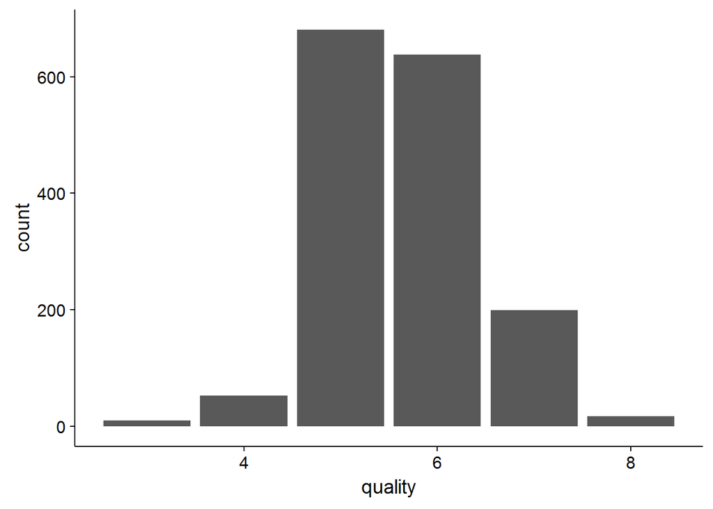

# Quality Distribution of Wines Bar Graph

Bulk of quality scores occur between 5-6. Mean of 5.6 with the low being a 3 and the high score being an 8.

### Did you create any new variables from existing variables in the dataset?

```r
#Create new variables: total acid and convert quality to a numerical number
wine$total.acid <- wine$fixed.acidity+wine$volatile.acidity
wine$quality_number <- as.numeric(wine$quality)
wine$quality_rating <- ifelse(wine$quality <= 4, 'bad', ifelse(
  wine$quality <= 7, 'ok', 'good'))
wine$quality_resize = factor(wine$quality_rating,
                             levels=c('bad','ok','good'))
```

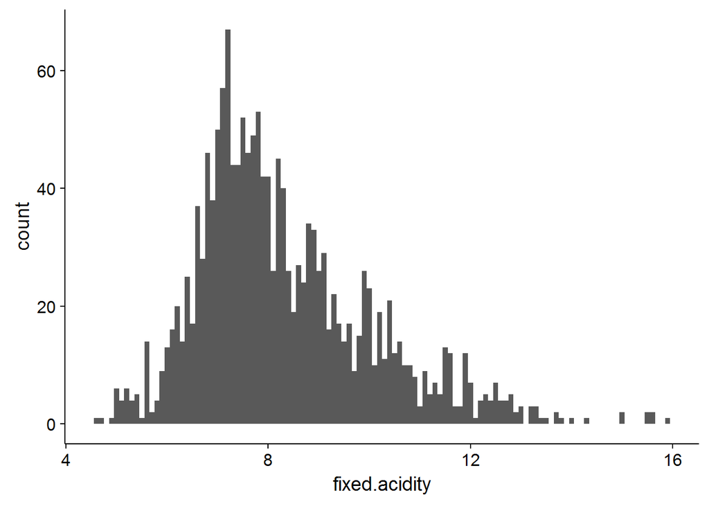

```
##    Min. 1st Qu.  Median    Mean 3rd Qu.    Max.
##    4.60    7.10    7.90    8.32    9.20   15.90
```

## Fixed Acidity

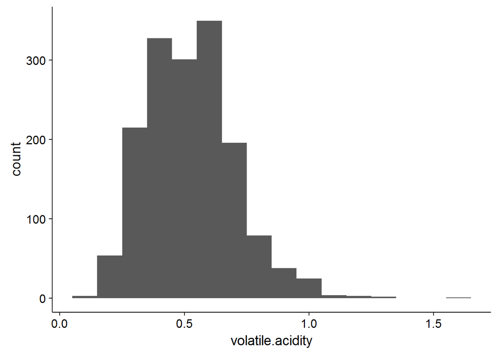

```
##    Min. 1st Qu.  Median    Mean 3rd Qu.    Max.
##  0.1200  0.3900  0.5200  0.5278  0.6400  1.5800
```

## Volatile Acidity

Has tails on either end of the distribution. The mean is .52 g/dm3 with a low of .12 g/dm3 and a high of 1.58 g/dm3. Less volatile acidity than fixed acidity in red wines of this dataset.

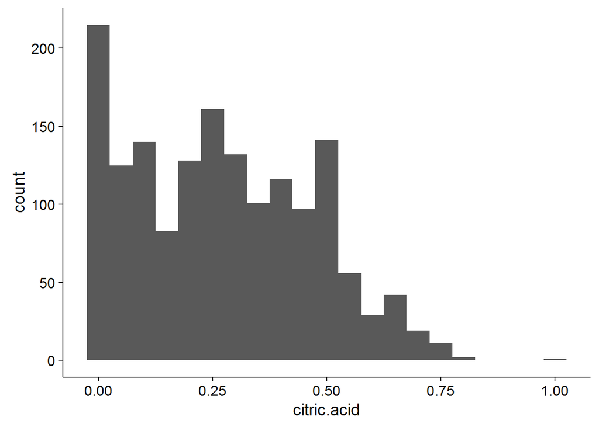

```
##    Min. 1st Qu.  Median    Mean 3rd Qu.    Max.
##   0.000   0.090   0.260   0.271   0.420   1.000
```

## Citric acid

More than 200 wines have between 0 and 0.05 g/dm3 of citric acid. Makes me question whether these wines have missing data points or minimal acid content. Avg of .26 g/dm3 citric acid in these wines.

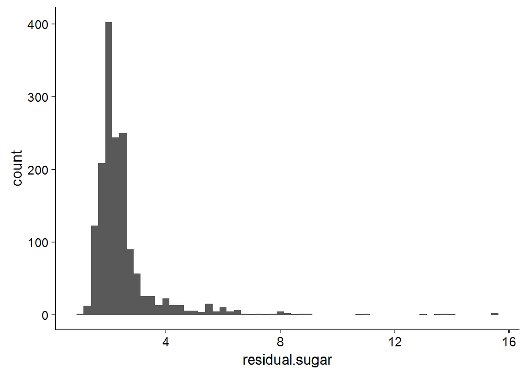

```
##    Min. 1st Qu.  Median    Mean 3rd Qu.    Max.
##   0.900   1.900   2.200   2.539   2.600  15.500
```

## Residual Sugar

A lot of outlers here. We have wines exceeding 12 g/dm3 while the bulk of the data has less than 4 g/dm3.

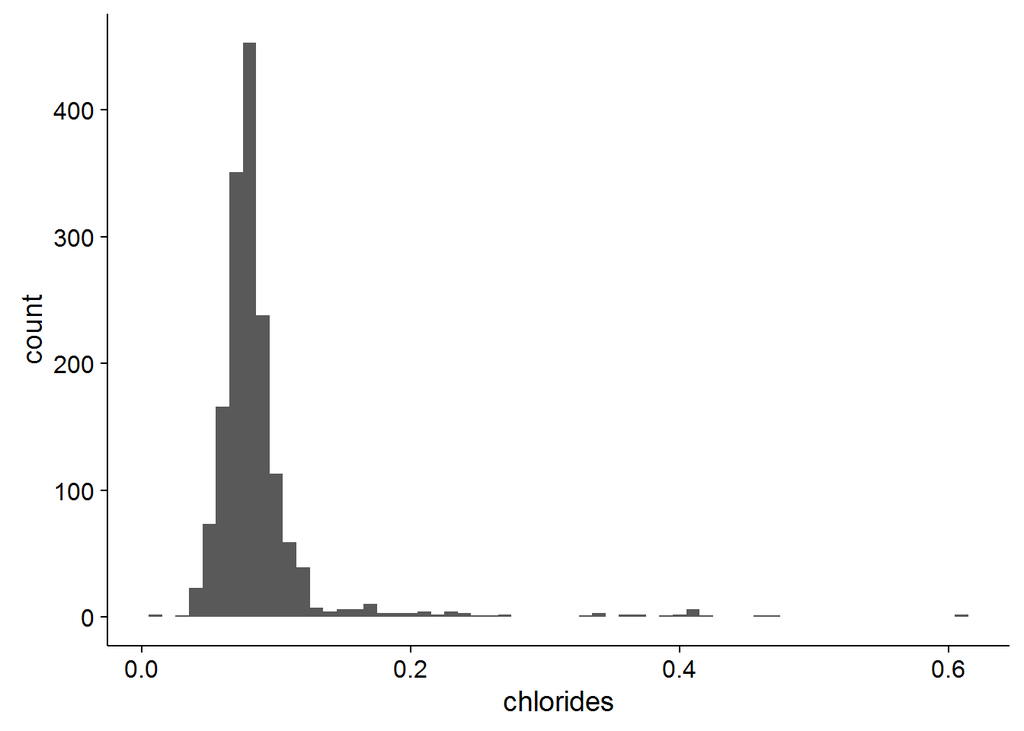

```
##    Min. 1st Qu.  Median    Mean 3rd Qu.    Max.
## 0.01200 0.07000 0.07900 0.08747 0.09000 0.61100
```

## Chlorides

Similar outlook as sugar. Several wines exceed 0.2 g/dm3 while bulk of data has less than .15 g/dm3.

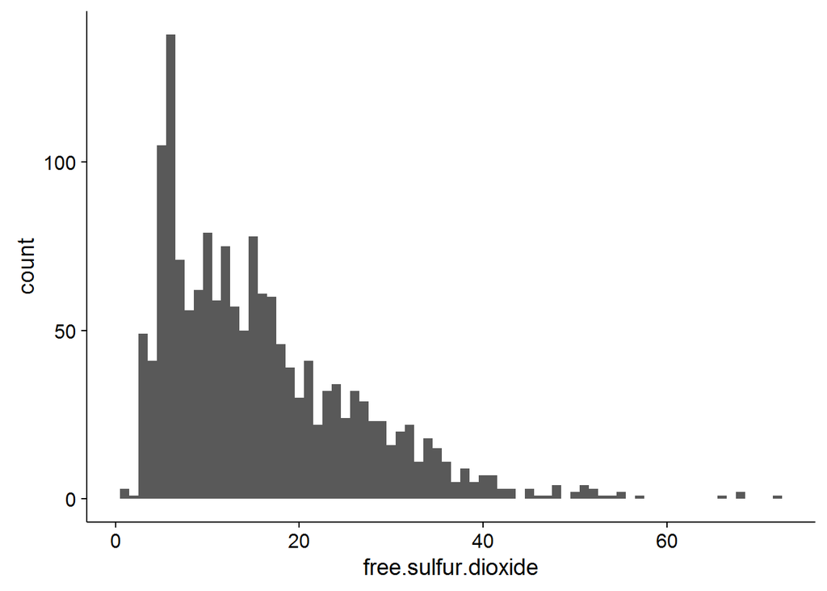

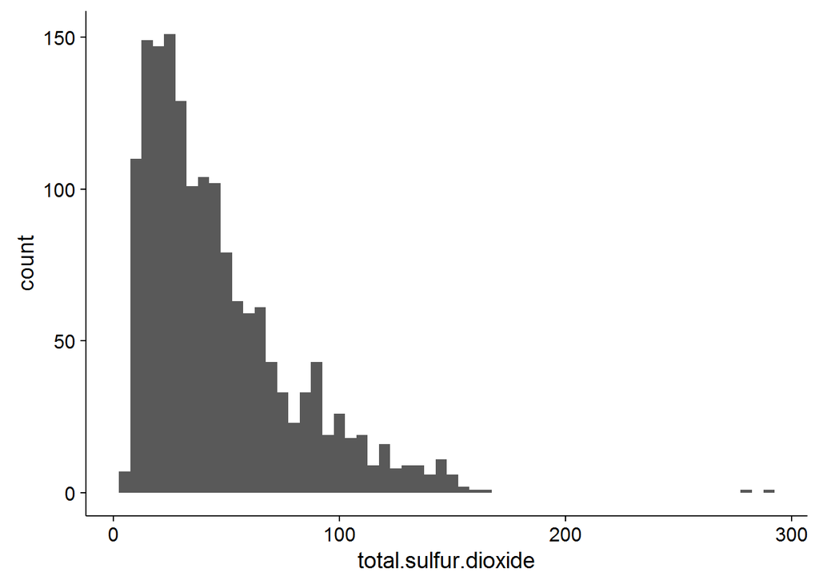

```
##    Min. 1st Qu.  Median    Mean 3rd Qu.    Max.
##    6.00   22.00   38.00   46.47   62.00  289.00
```

## Sulfur dioxide

Free and total sulfur dioxides have similar distributions with outliers on the tail end of the distribution.

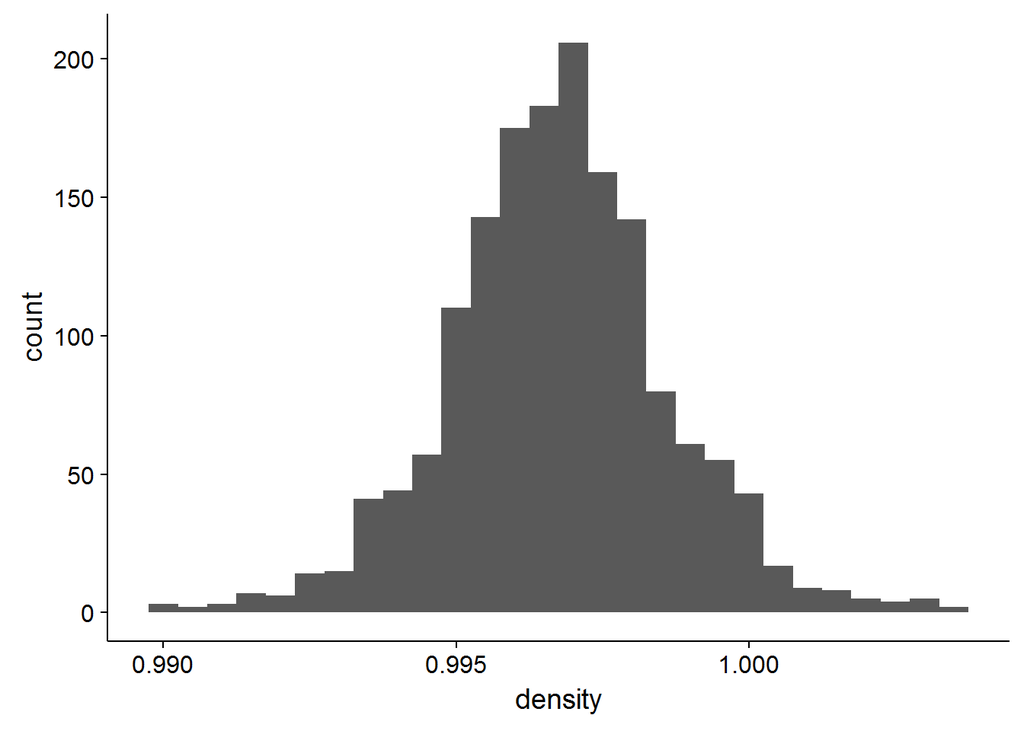

```
##    Min. 1st Qu.  Median    Mean 3rd Qu.    Max.
##  0.9901  0.9956  0.9968  0.9967  0.9978  1.0040
```

## Density

Normal distribution. Average of 0.9968 g/cm3 and tight data range.

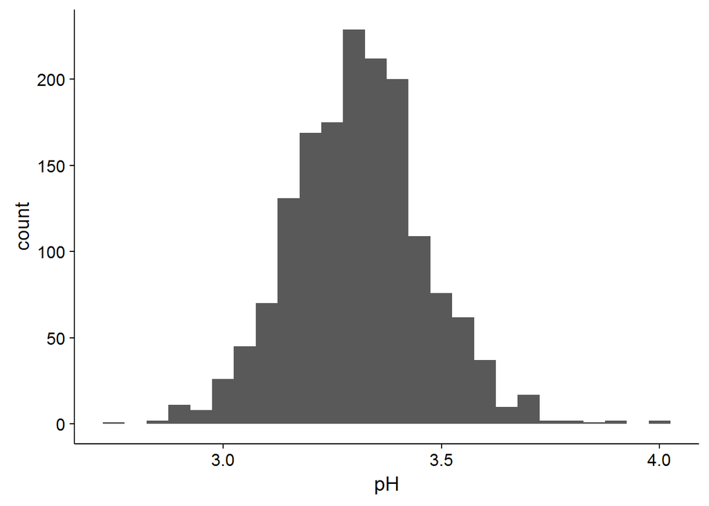

```
##    Min. 1st Qu.  Median    Mean 3rd Qu.    Max.
##   2.740   3.210   3.310   3.311   3.400   4.010
```

## pH

Normal distribution. All pHs fall within the acid range of the pH scale 2.7-4.0.

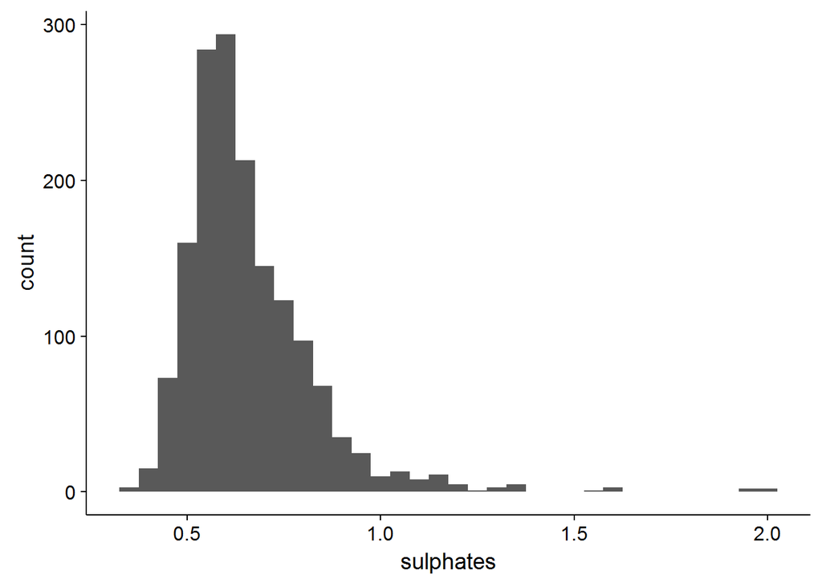

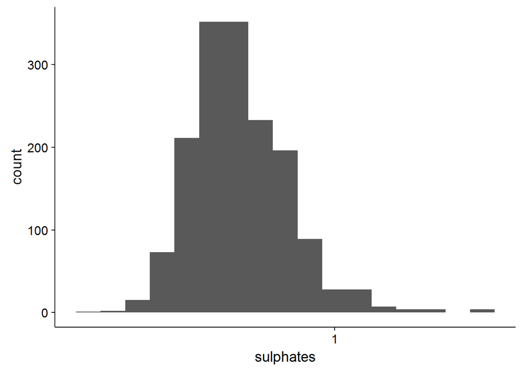

```
##    Min. 1st Qu.  Median    Mean 3rd Qu.    Max.
##  0.3300  0.5500  0.6200  0.6581  0.7300  2.0000
```

## Sulphates

Outliers on the right end of the distribution. Log transformation makes it more normal

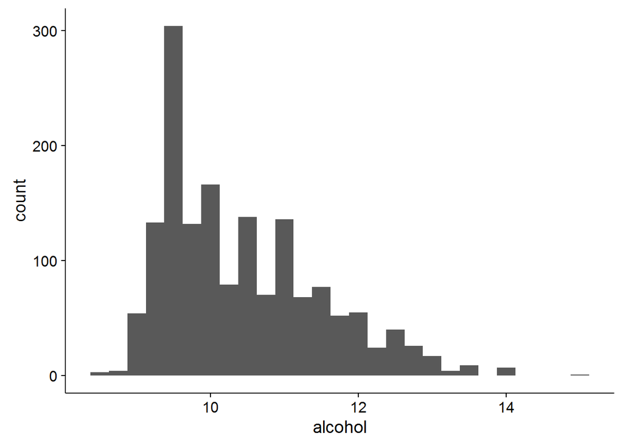

```
##    Min. 1st Qu.  Median    Mean 3rd Qu.    Max.
##    8.40    9.50   10.20   10.42   11.10   14.90
```

## Alcohol %

Skewed right distribution with outliers going past 14% alcohol by volume.

# Univariate Analysis

### What is/are the main feature(s) of interest in your dataset?

I would like to investigate which chemical properties influence the quality of wines. Starting at pH, sugar, alcohol, and sulfur content as I would expect those factors to have some influence on quality.

### What other features in the dataset do you think will help support your investigation into your feature(s) of interest?

I will also look into other chemical properties (chlorides, citric acid) as well to see if they affect quality scoring.

# Bivariate Plots Section

```
##     volatile acidity total sulfur dioxide              density
##          -0.39055778          -0.18510029          -0.17491923
##            chlorides                   pH  free sulfur dioxide
##          -0.12890656          -0.05773139          -0.05065606
##                sugar           Total Acid        fixed acidity
##           0.01373164           0.08570932           0.12405165
##          citric acid            sulphates              alcohol
##           0.22637251           0.30864193           0.47616632
```

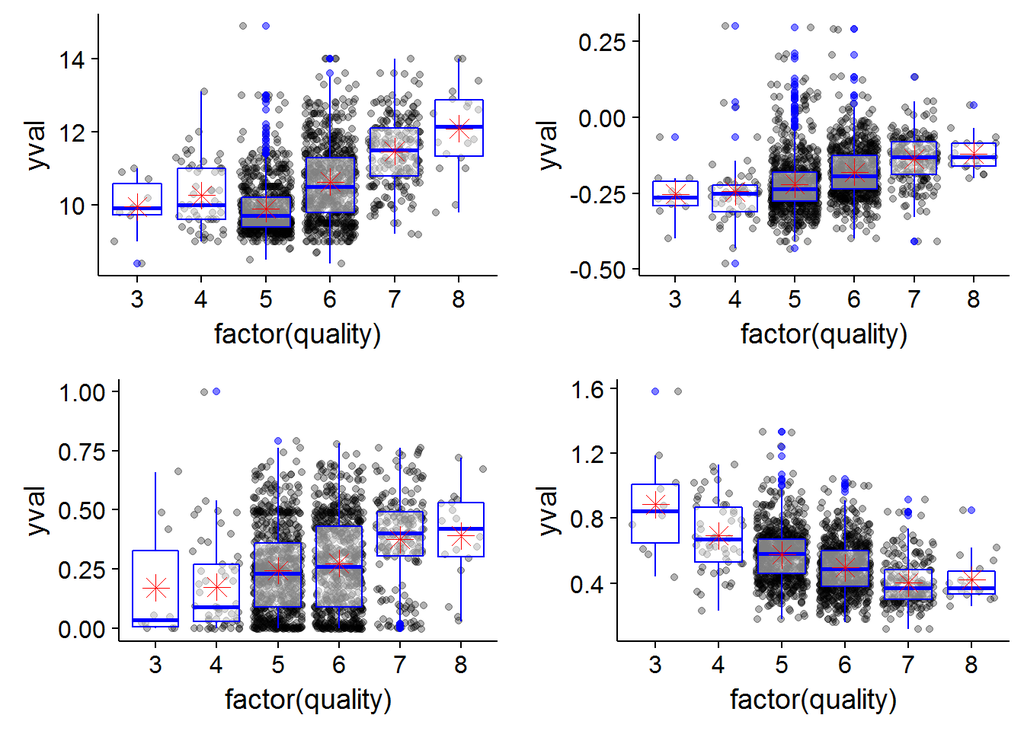

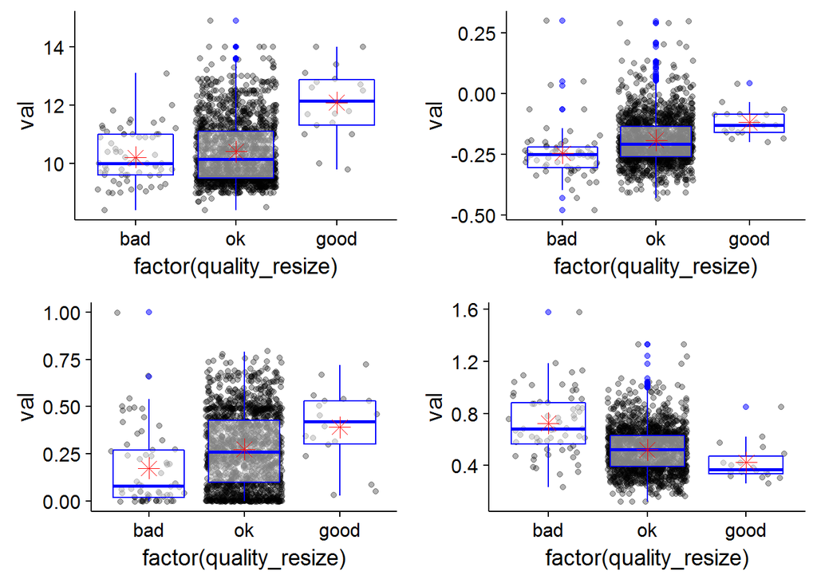

# Bivariate Analysis

### Multivariate Plots Section

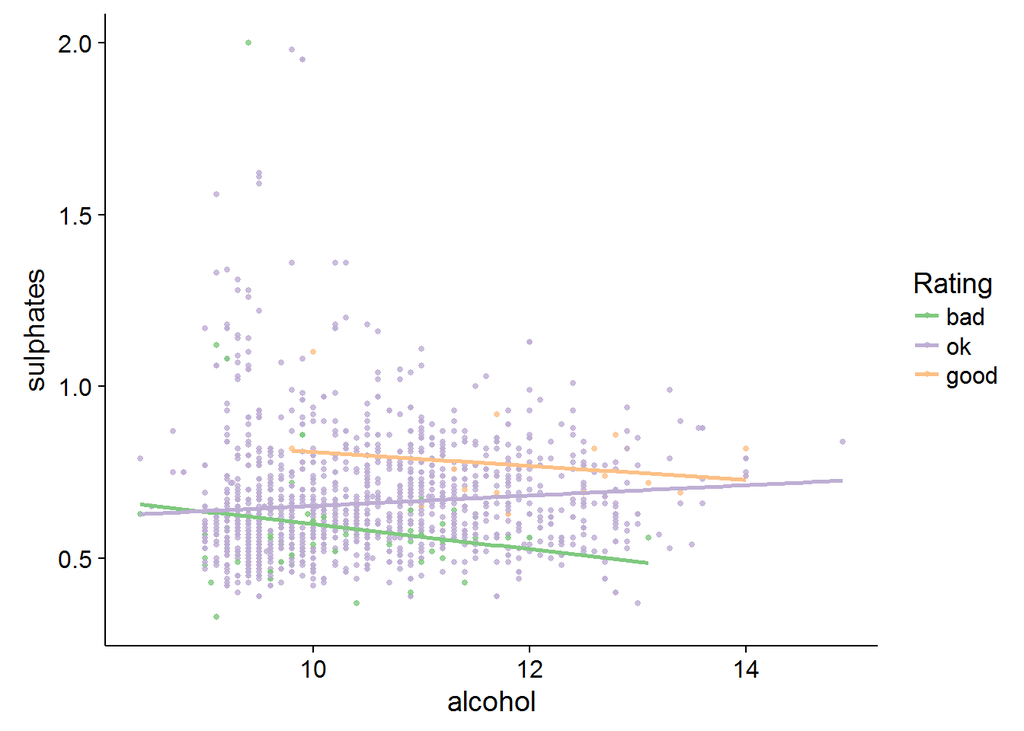

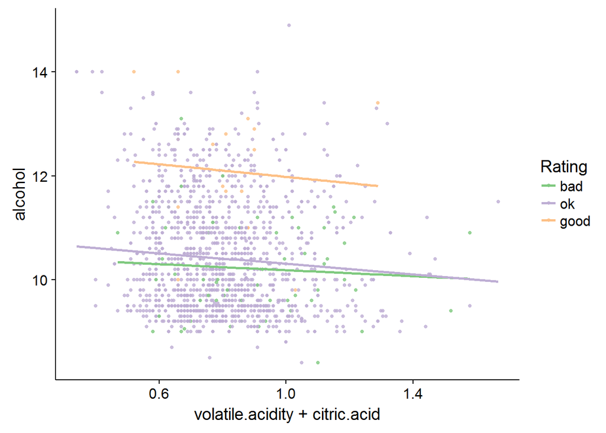

# Multivariate Analysis

# Final Plots and Summary

### Distribution of wine quality in dataset

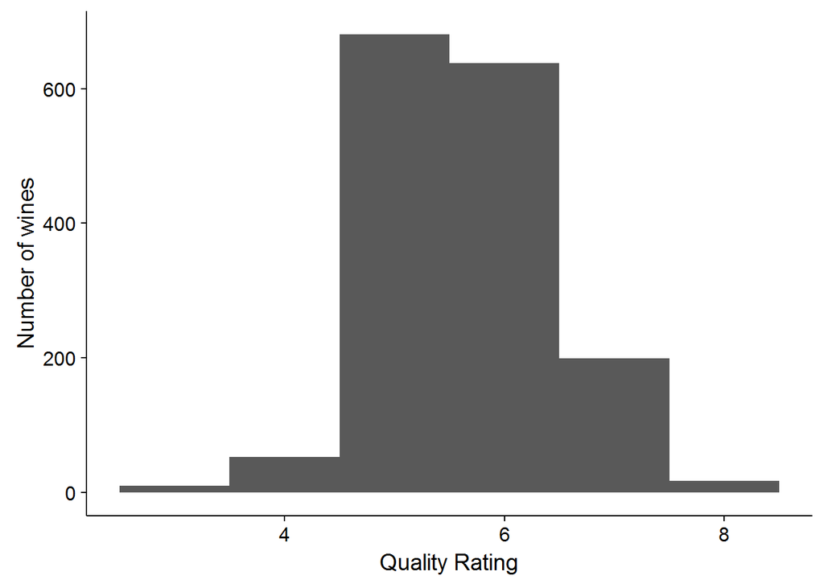

### Description

This histogram quickly explains the wine dataset we are working with. Any conclusions made from this data exploration will be most accurate when applied to thinking about “average” wines as an overwhelming amount of wine data comes from wines scoring a 5 or a 6.

### Acid and Alcohol versus Quality

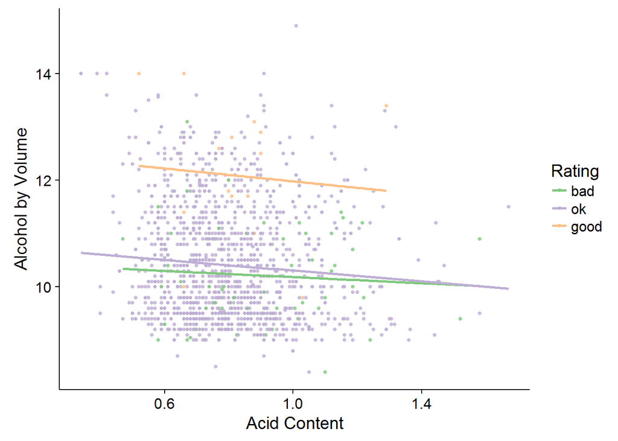

### Description

Building on explorations of acetic and citric acid effects on wine, I plot acid and alcohol and see how those two properties determine quality. For good wines (wines scoring 8 or above), alcohol content is higher in relation to ok or bad wines. Good wines also tend to have less acid content than bad wines, but it is hard to concretely conclude that without more data as the ok wines have even less acid content than the good wines.

### Sulphate Content by Quality

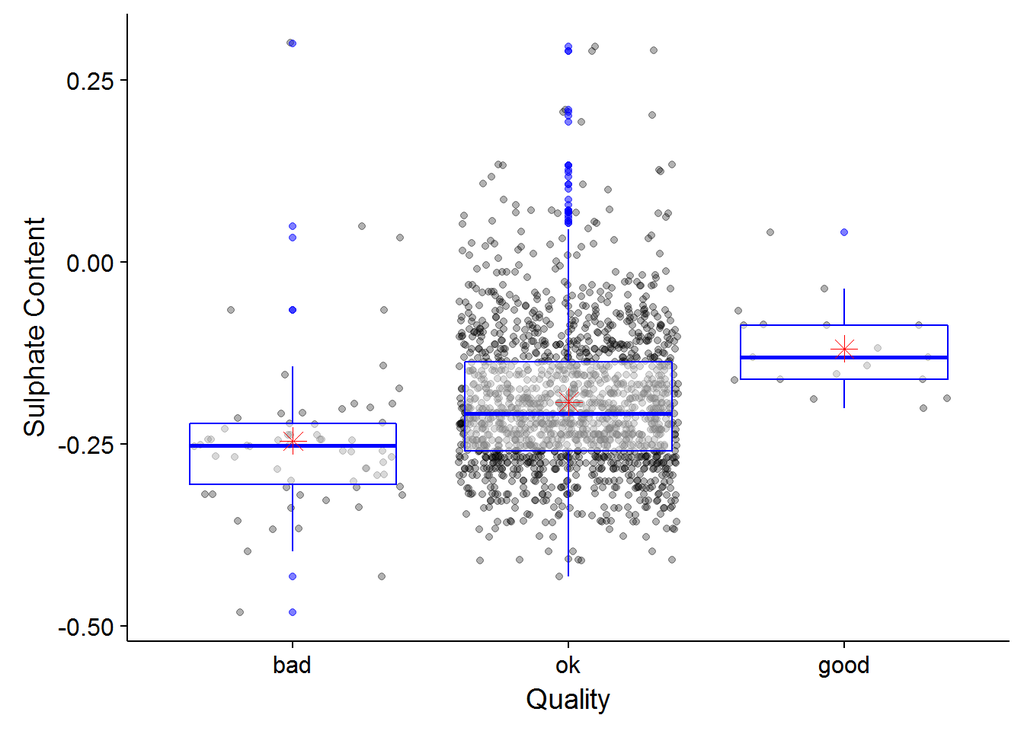

### Description

The best way to represent the different in sulphate content is to use the boxplots. We can see here that sulphates, a common preservative, plays a significant role in wine quality. The average sulphate content increases as we move from bad to good on the wine quality scale.

# Reflection

One of the biggest challenges I had to deal with analyzing this problem set was to constantly account for the fact that the bulk of data came from wines that were 5 or a 6 or deemed as “ok” in my explorations. Sometimes, the data points could imply a possible trend, but without enough data points from each category, it was difficult to conclude anything unless there was a clear trend. I found box plots to be fantastic in helping deal with this. The ability to compare averages and quartile ranges made it possible to compare wines based on quality.

Future work could be extended to getting relatively equal amounts of data for each wine quality score. I would also look into collecting and analyzing more categorical variables such as color and smell as I am aware that non-numerical variables are part of the wine tasting experience.